# Space-Time Prediction of Bike Share Demand

Lu Yii Wong

November 17, 2023

# 1: Introduction

Citi Bike is a bikeshare program that allows users to rent bikes across all boroughs of New York City, Jersey City, and Hoboken. How it works is that Citi Bike users can unlock a bike at any Citi Bike station through the Citi Bike app, ride it anywhere in the city, and return the bike by parking it at an available docking station.

Bikeshare programs like this have revolutionized the way people can get around the city. A major challenge that these programs face is “re-balancing”, which is ensuring that there are bikes where the demand is. Programs like Citi Bike can only be successful if they anticipate where demand for bikes are to ensure that users can ride whenever and wherever they are.

## 1.1: Use-Case Strategy

To address this issue, I attempt to build a predictive model using demand for bikes in Manhattan to show how we can use time-space predictive modeling to address an operations issue. With this information, Citi Bike can anticipate the time and location of high bike demand across the borough and move bikes to these locations at the appropriate times.

For this project, I focused on Manhattan Citi Bike demand. Manhattan is currently the most heavily trafficked Citi bike locations. To improve the current distribution of bikes in the city, I feel that using an example with the robust data set will allow us to come up with the strongest predictive model that can later be applied to other boroughs and areas which Citi bike serves. Due to the size of the data sets, I chose to look at Citi bike data from June to July 2023. I chose these months as the summer months are typically the most busy. Moreover, using the most up to date data can help create a more relevant model, as it might better reflect current demand patterns.

# 2: Data Processing

In this section, I download all the necessary data. For this project, I used data from the Citi Bike, the 2021 Census, and weather data.

## 2.1 Set-up

```r
library(tidyverse)
library(sf)
library(lubridate)
library(tigris)
library(tidycensus)
library(viridis)
library(riem)
library(gridExtra)
library(knitr)
library(kableExtra)
library(RSocrata)
library(gganimate)
library(gifski)
library(ggplot2)

plotTheme <- theme(
  plot.title =element_text(size=12),
  plot.subtitle = element_text(size=8),
  plot.caption = element_text(size = 6),
  axis.text.x = element_text(size = 10, angle = 45, hjust = 1),
  axis.text.y = element_text(size = 10),
  axis.title.y = element_text(size = 10),
  # Set the entire chart region to blank
  panel.background=element_blank(),
  plot.background=element_blank(),
  #panel.border=element_rect(colour="#F0F0F0"),
  # Format the grid
  panel.grid.major=element_line(colour="#D0D0D0",size=.2),
  axis.ticks=element_blank())

mapTheme <- theme(plot.title =element_text(size=12),
                  plot.subtitle = element_text(size=8),
                  plot.caption = element_text(size = 6),
                  axis.line=element_blank(),
                  axis.text.x=element_blank(),
                  axis.text.y=element_blank(),
                  axis.ticks=element_blank(),
                  axis.title.x=element_blank(),
                  axis.title.y=element_blank(),
                  panel.background=element_blank(),
                  panel.border=element_blank(),
                  panel.grid.major=element_line(colour = 'transparent'),
                  panel.grid.minor=element_blank(),
                  legend.direction = "vertical",
                  legend.position = "right",
                  plot.margin = margin(1, 1, 1, 1, 'cm'),
                  legend.key.height = unit(1, "cm"), legend.key.width = unit(0.2, "cm"))

palette5 <- c("#eff3ff","#bdd7e7","#6baed6","#3182bd","#0050B5")
palette4 <- c("#D2FBD4","#92BCAB","#527D82","#123F5A")
palette2 <- c("#6baed6","#0050B5","#123F5A" )
```

## 2.2: Importing Citibike Data

```r
# citi bike july and june original data
# subset to week 24 to week 28, Jun.11 - Jul.15)

dat.june <- read.csv("202306-citibike-tripdata.csv")
dat.july <- read.csv("202307-citibike-tripdata.csv")
dat <-rbind(dat.june, dat.july) %>%
  mutate(interval60 = floor_date(ymd_hms(started_at), unit = "hour"),
         interval15 = floor_date(ymd_hms(started_at), unit = "15 mins"),
         week = week(interval60),
         dotw = wday(interval60, label=TRUE)) %>%
  dplyr::select(-ride_id, -rideable_type, -member_casual) %>%
  filter(week > 23 & week < 29) %>%
  na.omit()

rm(dat.june)
rm(dat.july)
```

## 2.3: Import Census Information

Here, I downloaded New York County data, which is Manhattan data. I downloaded 2021 American Community Survey data from the Census Bureau (https://data.census.gov/). Some variables that I considered included total population, median income, median age, means of transportation, and more. Using the data from the census, I found the following:

- `Percent_White`: The percentage of white population out of the total population
- `Mean_Commute_Time`: The mean commute time for those commuting by public transit
- `Percent_Taking_Public_Trans`: Percentage of commuters commuting by public transit

Additionally, using the `nycCensus`, I set the boundaries for Manhattan.

```r
# get new york county data
nycCensus <-
  get_acs(geography = "tract",
          variables = c("B01003_001", "B19013_001",
                        "B02001_002", "B08013_001",
                        "B08012_001", "B08301_001",
                        "B08301_010", "B01002_001"),
          year = 2021,
          state = "New York",
          county = "New York County",
          geometry = TRUE,
          output = "wide") %>%
  rename(Total_Pop =  B01003_001E,
         Med_Inc = B19013_001E,
         Med_Age = B01002_001E,
         White_Pop = B02001_002E,
         Travel_Time = B08013_001E,
         Num_Commuters = B08012_001E,
         Means_of_Transport = B08301_001E,
         Total_Public_Trans = B08301_010E) %>%
  select(Total_Pop, Med_Inc, White_Pop, Travel_Time,
         Means_of_Transport, Total_Public_Trans,
         Med_Age,
         GEOID, geometry) %>%
  mutate(Percent_White = White_Pop / Total_Pop,
         Mean_Commute_Time = Travel_Time / Total_Public_Trans,
         Percent_Taking_Public_Trans = Total_Public_Trans / Means_of_Transport)

nycCensus <- st_set_crs(nycCensus, 4326)


#get the nyc tract range
nycTracts <-
  nycCensus %>%
  as.data.frame() %>%
  distinct(GEOID, .keep_all = TRUE) %>%
  select(GEOID, geometry) %>%
  st_sf

# get the entire range for st_intersection below
nycBoundary <- st_union(nycTracts)
```

### 2.3.1: Exploring Census Patterns

Using the census data, I plot the commuting patterns in Manhattan, as seen in Figure 2.1.1 and 2.1.2. Figure 2.1.1 gives us an idea on areas in Manhattan that have higher dependence on public transit. The areas in dark blue indicate the highest reliance on public transit, with the largest concentration of commuters seen in Harlem and the upper East and West sides of Manhattan. Figure 2.1.2 shows the average commute time by minutes. Here, we see that mean commute times are generally less than an hour long. Ideally, with greater access to public transit, we would be able to reduce overall mean commute times.

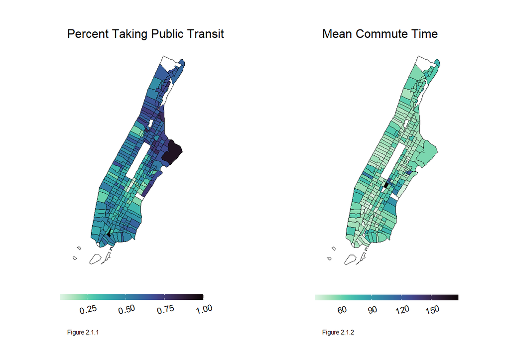

```r
# Commuting patterns using census data

grid.arrange(
  ggplot() +
    geom_sf(data = nycCensus, aes(fill = Percent_Taking_Public_Trans),
            color = "black") +
    scale_fill_viridis(direction = -1, option = "G", na.value = "white") +
    labs(title = "Percent Taking Public Transit", fill="",
         caption = "Figure 2.1.1") +
    mapTheme +
    theme(plot.caption = element_text(hjust = 0),
          panel.grid.major = element_blank(),
          strip.background = element_blank(),
          legend.position = "bottom",
          legend.direction = "horizontal",
          legend.box = "horizontal",
          legend.text = element_text(angle = 15),
          legend.key.width = unit(1, "cm"),
          legend.key.height = unit(0.2, "cm")),

  map3 <- ggplot() +
    geom_sf(data = nycCensus, aes(fill = Mean_Commute_Time),
            color = "black") +
    scale_fill_viridis(direction = -1,option = "G", na.value = "white") +
    labs(title = "Mean Commute Time", fill="",
         caption = "Figure 2.1.2") +
    mapTheme+
    theme(plot.caption = element_text(hjust = 0),
          panel.grid.major = element_blank(),
          strip.background = element_blank(),
          legend.position = "bottom",
          legend.direction = "horizontal",
          legend.box = "horizontal",
          legend.text = element_text(angle = 15),
          legend.key.width = unit(1, "cm"),
          legend.key.height = unit(0.2, "cm")), ncol=2)
```

I also looked at some of the socio-economic patterns, as I felt that this might give us insight into commuting patterns. Figure 2.2.1 shows the concentration of white population across Manhattan. Figure 2.2.2 shows the Median Household income by Census Tract.

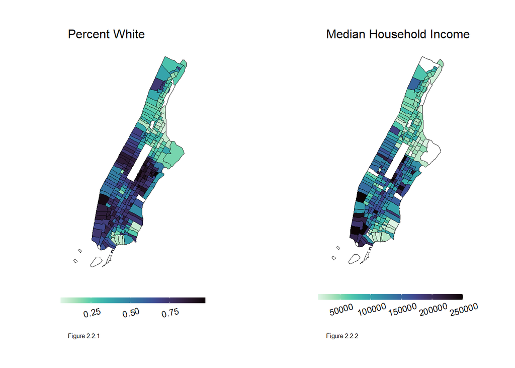

```r
# Socio-economic patterns using Census data

grid.arrange(
  ggplot() +
    geom_sf(data = nycCensus, aes(fill = Percent_White),
            color = "black") +
    scale_fill_viridis(direction = -1, option = "G", na.value = "white") +
    labs(title = "Percent White", fill="",
         caption = "Figure 2.2.1") +
    mapTheme+
    theme(plot.caption = element_text(hjust = 0),
          panel.grid.major = element_blank(),
          strip.background = element_blank(),
          legend.position = "bottom",
          legend.direction = "horizontal",
          legend.box = "horizontal",
          legend.text = element_text(angle = 15),
          legend.key.width = unit(1, "cm"),
          legend.key.height = unit(0.2, "cm")),

  map4 <- ggplot() +
    geom_sf(data = nycCensus, aes(fill = Med_Inc),
            color = "black") +
    scale_fill_viridis(direction = -1,option = "G", na.value = "white") +
    labs(title = "Median Household Income", fill="",
         caption = "Figure 2.2.2") +
    mapTheme+
    theme(plot.caption = element_text(hjust = 0),
          panel.grid.major = element_blank(),
          strip.background = element_blank(),
          legend.position = "bottom",
          legend.direction = "horizontal",
          legend.box = "horizontal",
          legend.text = element_text(angle = 15),
          legend.key.width = unit(1, "cm"),
          legend.key.height = unit(0.2, "cm")), ncol=2)
```

## 2.4: Data Cleaning

To ensure that the data I am working with is useful, I had to do significant data cleaning. For the current use case, I am only concerned about Manhattan Citi bike ridership patterns. As such, I made a subset of the Citi bike data to reflect only Manhattan rides, by dropping all trips that started or ended outside of Manhattan. While going through the data, I also realized that there were a lot of incomplete data sets. Considering that our existing data set is very robust, I decided to drop all empty values.

```r
# subset the data only to Manhattan, dropping starting and ending point in brooklyn
dat2 <- dat %>%
  # drop starting points
  filter(!is.na(start_lng) & !is.na(start_lat)) %>%
  st_as_sf(., coords = c("start_lng", "start_lat"), crs = 4326) %>%
  st_intersection(., nycBoundary) %>%
   # get lng lat back
  st_transform(., crs = 4326) %>%
  mutate(start_lng = st_coordinates(.)[, "X"],
         start_lat = st_coordinates(.)[, "Y"]) %>%
  as.data.frame() %>%
  select(-geometry) %>%
  # drop ending points
  filter(!is.na(end_lng) & !is.na(end_lat)) %>%
  st_as_sf(coords = c("end_lng", "end_lat"), crs = 4326) %>%
  st_intersection(., nycBoundary) %>%
    # get lng lat back
  st_transform(., crs = 4326) %>%
  mutate(end_lng = unlist(map(geometry, 1)),
         end_lat = unlist(map(geometry, 2))) %>%
  as.data.frame() %>%
  select(-geometry)

# remove empty values and align lat and lng for points
dat2 <- dat2 %>%
  filter(start_station_name != "" & end_station_name != "") %>%
  group_by(start_station_name) %>%
  mutate(start_lng = mean(start_lng),
         start_lat = mean(start_lat)) %>%
  ungroup() %>%
  group_by(end_station_name) %>%
  mutate(end_lng = mean(end_lng),
         end_lat = mean(end_lat)) %>%
  ungroup()

rm(dat)
```

```r
# removing NA values

dat2 <- st_join(dat2 %>%
          filter(is.na(start_lng) == FALSE &
                   is.na(start_lat) == FALSE &
                   is.na(end_lat) == FALSE &
                   is.na(end_lng) == FALSE) %>%
          st_as_sf(., coords = c("start_lng", "start_lat"), crs = 4326),
        nycTracts %>%
          st_transform(crs=4326),
        join=st_intersects,
              left = TRUE) %>%
  rename(start_Tract = GEOID) %>%
  mutate(start_lng = unlist(map(geometry, 1)),
         start_lat = unlist(map(geometry, 2)))%>%
  as.data.frame() %>%
  select(-geometry)
```

### 2.4.1: Visualizing Bikeshare Demand

Figure 2.3.1 shows where all existing Citi Bike docking stations are located in Manhattan. Here, we see that there is a good distribution of stations throughout the city. However, stations seem to be concentrated towards the center of the city, with few stations lining the edges of the city. It is interesting to note that the concentration of docking stations do not align with the areas that have the highest concentration of public transit commuters.

Figure 2.3.2 illustrates the demand of bikes by station. The larger and darker the points are on the map, the higher the number of total trips are taken from that station. According to this map, we see that most trips in Manhattan are concentrated between lower Manhattan and Midtown. The least number of trips are observed in the upper parts of Manhattan.

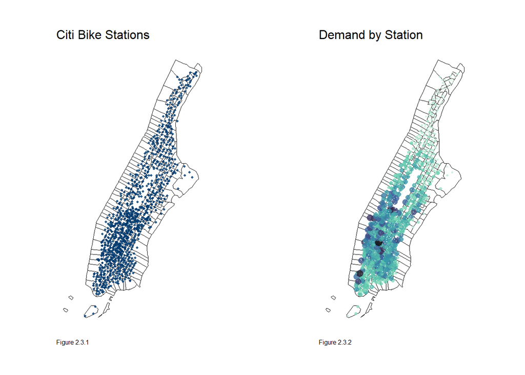

```r
# get the station locations
station_sf <- dat2 %>%
  distinct(start_station_id, .keep_all = TRUE) %>%
  st_as_sf(coords = c("start_lng", "start_lat"), crs = 4326)

trips <- dat2 %>%
  mutate(TripCount = 1) %>%
  group_by(start_station_name) %>%
  summarize(TripCount = sum(TripCount)) %>%
  ungroup() %>%
  right_join(., station_sf)

grid.arrange(
ggplot() +
  geom_sf(data = nycTracts, fill = "white", color = "black") +
  geom_sf(data = station_sf, color = "#003B70", alpha = 0.8, size = 0.8) +
  labs(title = "Citi Bike Stations",
       caption = "Figure 2.3.1") +
  coord_sf(crs = 4326) +
  mapTheme +
  theme(plot.caption = element_text(hjust = 0)),
ggplot() +
    geom_sf(data = nycTracts, fill = "white", color = "black") +
    geom_sf(data = trips, aes(size = TripCount, fill = TripCount, geometry = geometry),
          pch = 21, colour = 'NA', alpha = 0.8) +
  scale_fill_viridis_c(direction = -1, option = "G", breaks = c(0, 750, 3500, 10000), guide = FALSE) +
  scale_size_continuous(range = c(0, 3), guide = FALSE) +
  labs(title = "Demand by Station",
       caption = "Figure 2.3.2") +
  coord_sf(crs = 4326) +
  mapTheme+
  theme(plot.caption = element_text(hjust = 0)), ncol=2)
```

## 2.5: Import Weather Data

Bike riding is a form of commute that will be significantly impacted by weather. As such, I want to incorporate weather data into the model. For this use case, I downloaded weather data for NYC using `reim_measures`. I used LaGuardia Airport weather as a proxy for New York City weather. I downloaded the weather data for the weeks that are being studied.

Figure 2.4 shows the overall weather patterns in New York City between June and July 2023. The figure shows the trends in precipitation, wind speed, and temperature during our study period. As we see, June is a dry month, with little rainfall, however, in July there are days with heavy rainfall. Overall, the wind speed and temperature patterns remain relatively consistent, discounting the time-related fluctuations.

```r
weather.Panel <-
  riem_measures(station = "LGA", date_start = "2023-06-11", date_end = "2023-07-15") %>%
  dplyr::select(valid, tmpf, p01i, sknt)%>%
  replace(is.na(.), 0) %>%
    mutate(interval60 = ymd_h(substr(valid,1,13))) %>%
    mutate(week = week(interval60),
           dotw = wday(interval60, label=TRUE)) %>%
    group_by(interval60) %>%
    summarize(Temperature = max(tmpf),
              Precipitation = sum(p01i),
              Wind_Speed = max(sknt)) %>%
    mutate(Temperature = ifelse(Temperature == 0, 42, Temperature))
```

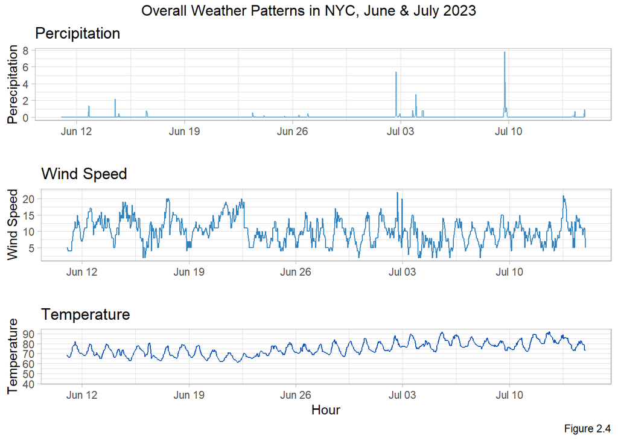

```r
#visualize overall trend
grid.arrange(
  ggplot(weather.Panel, aes(interval60,Precipitation)) +
    geom_line(color = "#6baed6") +
    labs(title="Percipitation", x="", y="Perecipitation") +
    theme_light(),
  ggplot(weather.Panel, aes(interval60,Wind_Speed)) +
    geom_line(color = "#3182bd") +
    labs(title="Wind Speed", x="", y="Wind Speed") +
    theme_light(),
  ggplot(weather.Panel, aes(interval60,Temperature)) +
    geom_line(color = "#0050B5") +
    labs(title="Temperature", x="Hour", y="Temperature", caption = "Figure 2.4") +
    theme_light(),
  top="Overall Weather Patterns in NYC, June & July 2023")
```

## 2.6: Space-Time Panel

To create a model, I created a study panel that includes all weeks of bike trips observed in Manhattan. To create the study panel, I grouped all trips into hourly intervals by the starting station of the trip. I also created a ride panel that merges the space-time intervals by actual trips observed. The ride.panel shows the number of trips that occur at a station, categorized by hour. The following information is also provided:

- `start_station_id`: The unique station id where each trip begins
- `start_station_name`: The name of the station where each trip begins
- `start_lng`: Longitude of starting station
- `start_lat`: Latitude of starting station
- `Trip_Count`: The number of trips observed by station by hour interval
- `weather.Panel`: Weather during given observation, including temperature, precipitation, and wind speed
- `week`: Week of observation
- `dotw`: Day of the week of observation

```r
study.panel <-
  expand.grid(interval60=unique(dat2$interval60),
              start_station_name = unique(dat2$start_station_name)) %>%
  left_join(., dat2 %>%
              select(start_station_id, start_station_name, start_lng, start_lat, start_Tract)%>%
              distinct() %>%
              group_by(start_station_name) %>%
              slice(1))
```

```r
ride.panel <-
  dat2 %>%
  mutate(Trip_Counter = 1) %>%
  right_join(study.panel) %>%
  group_by(interval60, start_station_id, start_station_name, start_lng, start_lat, start_Tract) %>%
  summarize(Trip_Count = sum(Trip_Counter, na.rm=T)) %>%
  left_join(weather.Panel) %>%
  ungroup() %>%
  filter(is.na(start_station_id) == FALSE) %>%
  mutate(week = week(interval60),
         dotw = wday(interval60, label = TRUE))

ride.panel <-
  left_join(ride.panel, nycCensus %>%
              as.data.frame() %>%
              select(-geometry), by = c("start_Tract" = "GEOID"))
```

## 2.7: Create time lags

```r
ride.panel <-
  ride.panel %>%
  arrange(start_station_id, interval60) %>%
  mutate(lagHour = dplyr::lag(Trip_Count,1),
         lag2Hours = dplyr::lag(Trip_Count,2),
         lag3Hours = dplyr::lag(Trip_Count,3),
         lag4Hours = dplyr::lag(Trip_Count,4),
         lag12Hours = dplyr::lag(Trip_Count,12),
         lag1day = dplyr::lag(Trip_Count,24),
         holiday = ifelse(yday(interval60) == 185,1,0))
# independence day in Jul.4 is the 185th day in 2023
```

```r
as.data.frame(ride.panel) %>%
    group_by(interval60) %>%
    summarise_at(vars(starts_with("lag"), "Trip_Count"), mean, na.rm = TRUE) %>%
    gather(Variable, Value, -interval60, -Trip_Count) %>%
    mutate(Variable = factor(Variable, levels=c("lagHour","lag2Hours","lag3Hours","lag4Hours",
                                                "lag12Hours","lag1day")))%>%
    group_by(Variable) %>%
    summarize(correlation = round(cor(Value, Trip_Count),2)) %>%
  kable() %>%
  kable_styling() %>%
  scroll_box(width = "500px", height = "200px")
```

| Variable | correlation |
| --- | --- |
| lagHour | 0.90 |
| lag2Hours | 0.69 |
| lag3Hours | 0.47 |
| lag4Hours | 0.26 |
| lag12Hours | -0.57 |
| lag1day | 0.88 |

# 3: Data Exploration

In this section, I take a deeper dive into the data. I want to understand variables that impact bike demand, so that we can build a more accurate and generalizable model that will predict bike demand by station.

## 3.1: Creating train and test sets

I split the data into training and test sets. In total, the study data includes a total of 5 weeks worth of data. The training set uses week 24 to 26 data and the test set uses week 27 and 28 data.

```r
# week 24-28 split into (24, 25, 26), and (27, 28)
ride.Train <- filter(ride.panel, week < 27)
ride.Test <- filter(ride.panel, week >= 27)
```

## 3.2: Bikeshare Ridership Demand Pattern

Figure 3.1 illustrates the daily bikeshare ridership observed in Manhattan form June to July 2023. As we can see, there is variation in demand by day. However, overall demand still seems to be concentrated between areas from lower Manhattan to Midtown. The darker areas on the map indicate stations with the highest number of trips per station per day.

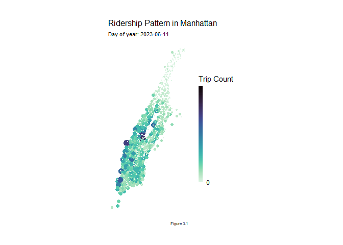

```r
ride.sum <- ride.panel %>%
                mutate(date = ymd(as.Date(interval60))) %>%
                group_by(date, start_station_name) %>%
                summarize(count = sum(Trip_Count)) %>%
                ungroup()

station_coords <- dat2 %>%
  select(start_station_name, start_lat, start_lng) %>%
  distinct()  # To make sure each station is represented only once

# Merge station coordinates with ride.sum
ride.sum <- ride.sum %>%
  left_join(station_coords, by = "start_station_name")

p <- ggplot() +
      geom_point(data = ride.sum,
                 aes(x = start_lng,
                     y = start_lat,
                     color = count, size = count),
  fill = "transparent")+
  scale_colour_viridis(direction = -1,
                       breaks = c(0, 750, 3500, 10000),
                       discrete = FALSE, option = "G") +
  scale_size_continuous(range = c(0.1, 4.5), guide = FALSE) +
  transition_states(date,
                    transition_length = 5,
                    state_length = 1) +
  enter_fade() +
  exit_fade() +
  labs(title = "Ridership Pattern in Manhattan",
       subtitle = "Day of year: {closest_state}",
       caption = "Figure 3.1",
       color = "Trip Count") +
  coord_sf(crs = 4326) +
  mapTheme

animate(p)
```

Figure 3.2 illustrates the daily bikeshare ridership patterns in Manhattan on one day of our training set. Here, we see the total bike pick-ups by station on the 21st of June 2023, a Wednesday. The trip count is shown at 15 minute intervals. We observe that the demand throughout the day changes, with the highest demands occurring in the morning and in the evening. This is likely due to commuting patterns. Commuters are more likely to ride a Citi Bike to and from work. The trends in high trip counts follow what has been observed previously, with the highest number of rides occurring between lower Manhattan and midtown.

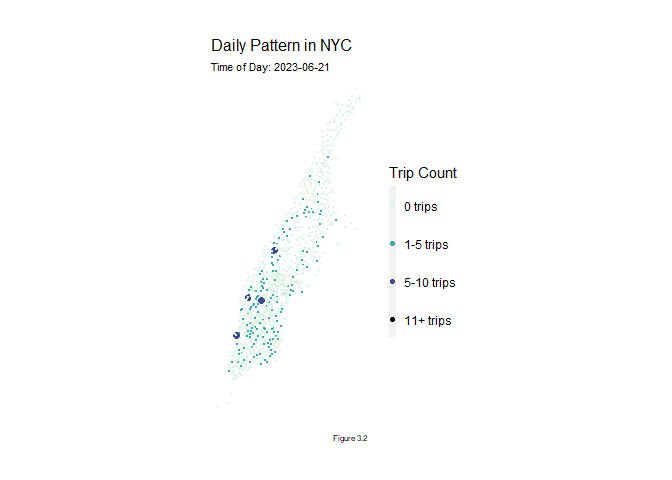

```r
week25 <-
  filter(dat2, week == 25 & dotw == "Wed")

week25.panel <-
  expand.grid(
    interval15 = unique(week25$interval15),
    start_station_name = unique(dat2$start_station_name))

ride.animation.data <-
  mutate(week25, Trip_Counter = 1) %>%
    right_join(week25.panel) %>%
    group_by(interval15, start_station_name) %>%
    summarize(Trip_Count = sum(Trip_Counter, na.rm=T)) %>%
    mutate(Trips = case_when(Trip_Count == 0 ~ "0 trips",
                             Trip_Count > 0 & Trip_Count <= 5 ~ "1-5 trips",
                             Trip_Count > 5 & Trip_Count <= 10 ~ "5-10 trips",
                             Trip_Count > 10 ~ "11+ trips")) %>%
    mutate(Trips  = fct_relevel(Trips, "0 trips","1-5 trips","5-10 trips",
                                      "11+ trips"))

station_coords <- dat2 %>%
  select(start_station_name, start_lat, start_lng) %>%
  distinct()

# Merge station coordinates with ride.animation.data
ride.animation.data <- ride.animation.data %>%
  left_join(station_coords, by = "start_station_name")

size_values <- c("0 trips" = 0.1, "1-5 trips" = 0.4, "5-10 trips" = 2, "11+ trips" = 4.5)

p1 <-
  ggplot() +
    geom_point(data = ride.animation.data,
            aes(x = start_lng,
                     y = start_lat,
                     color = Trips, size = Trips),
            fill = "transparent") +
   scale_colour_viridis(direction = -1,
                       discrete = TRUE, option = "G") +
  scale_size_manual(values = size_values, guide = FALSE) +
    labs(title = "Rideshare Pickups On One Day in June 2023",
         subtitle = "15 minute intervals: {current_frame}",
         caption = "Figure 3.2") +
    transition_states(interval15,
                    transition_length = 5,
                    state_length = 10) +
  enter_fade() +
  exit_fade() +
  labs(title = "Daily Pattern in NYC",
       subtitle = "Time of Day: {closest_state}",
       color = "Trip Count") +
  coord_sf(crs = 4326) +
  mapTheme

animate(p1)
```

## 3.3: Trips by Time

Figure 3.3 shows overall trip counts by week for our training and test sets. From this figure, we can deduce that there is a relationship between time and demand. We see that demand is not constant, and that during different times of day, demand drops and spikes. Moreover, there seems to pattern between day of week and demand. Ridership demand seems to be highest during the week, between Tuesdays and Thursdays, while overall ridership drops on the weekend. From this, we can infer that incorporating temporal features will be important for our model.

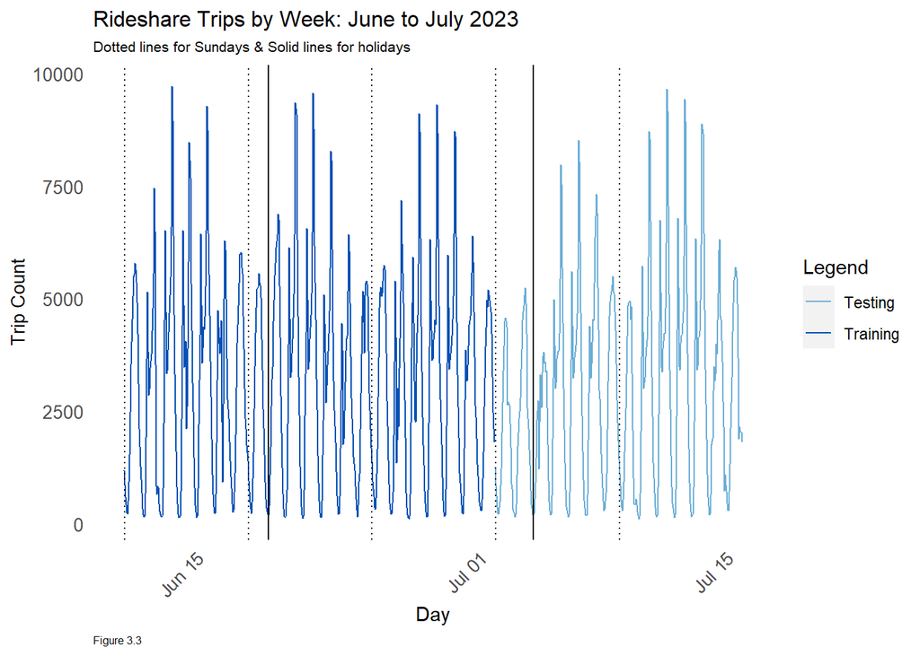

```r
sundays <-
  mutate(dat2,
         sunday = ifelse(dotw == "Sun" & hour(interval60) == 1,
                         interval60, 0)) %>%
  filter(sunday != 0)

independentDay <- as.POSIXct("2023-07-04 00:00:00 UTC")
juneteenth <- as.POSIXct("2023-06-19 00:00:00 UTC")

rbind(
  mutate(ride.Train, Legend = "Training"),
  mutate(ride.Test, Legend = "Testing")) %>%
    group_by(Legend, interval60) %>%
      summarize(Trip_Count = sum(Trip_Count)) %>%
      ungroup() %>%
      ggplot(aes(interval60, Trip_Count, colour = Legend)) +
      geom_line() +
        scale_colour_manual(values = palette2) +
        geom_vline(xintercept = independentDay) +
        geom_vline(xintercept = juneteenth) +
        geom_vline(data = sundays, aes(xintercept = sunday), linetype = "dotted") +
        labs(title="Rideshare Trips by Week: June to July 2023",
             subtitle="Dotted lines for Sundays & Solid lines for holidays",
             caption = "Figure 3.3",
             x="Day", y="Trip Count") +
        plotTheme+
        theme(plot.caption = element_text(hjust = 0)) +
        theme(panel.grid.major = element_blank())
```

Figure 3.4 shows the total bike share trips per hour per station. This shows that there are a low number of trips occurring at most stations at a given time. This means that there are few stations that will experience a high demand in ridership at a given hour. Most stations in Manhattan will experience less than 40 trips per hour.

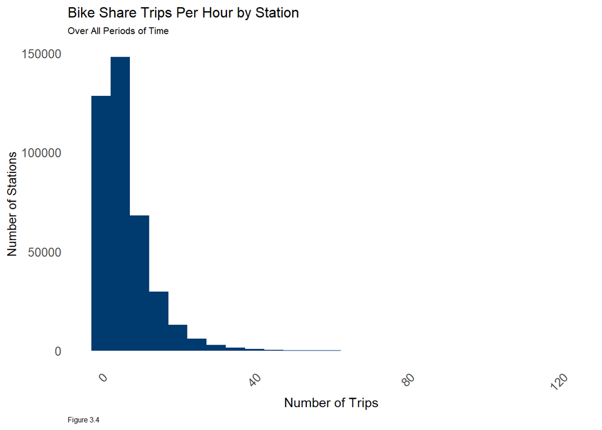

```r
ggplot(dat2 %>%
         group_by(interval60, start_station_name) %>%
         tally())+
  geom_histogram(aes(n), binwidth = 5, fill = "#003B70")+
  labs(title="Bike Share Trips Per Hour by Station",
       subtitle = "Over All Periods of Time",
       caption = "Figure 3.4",
       x="Number of Trips",
       y="Number of Stations")+
  plotTheme +
        theme(plot.caption = element_text(hjust = 0)) +
        theme(panel.grid.major = element_blank())
```

### 3.3.1: Trips by Time Period

Here, we see that the ridership patterns by station is relatively similar to those seen in Figure 3.4 across all four time periods. During the `AM Rush` and `PM Rush` periods, we see that there are more stations that have higher demand overall, but there are still a large number of stations that experience 0 trips. This highlights the fact that demand is not consistent across all stations at a given time.

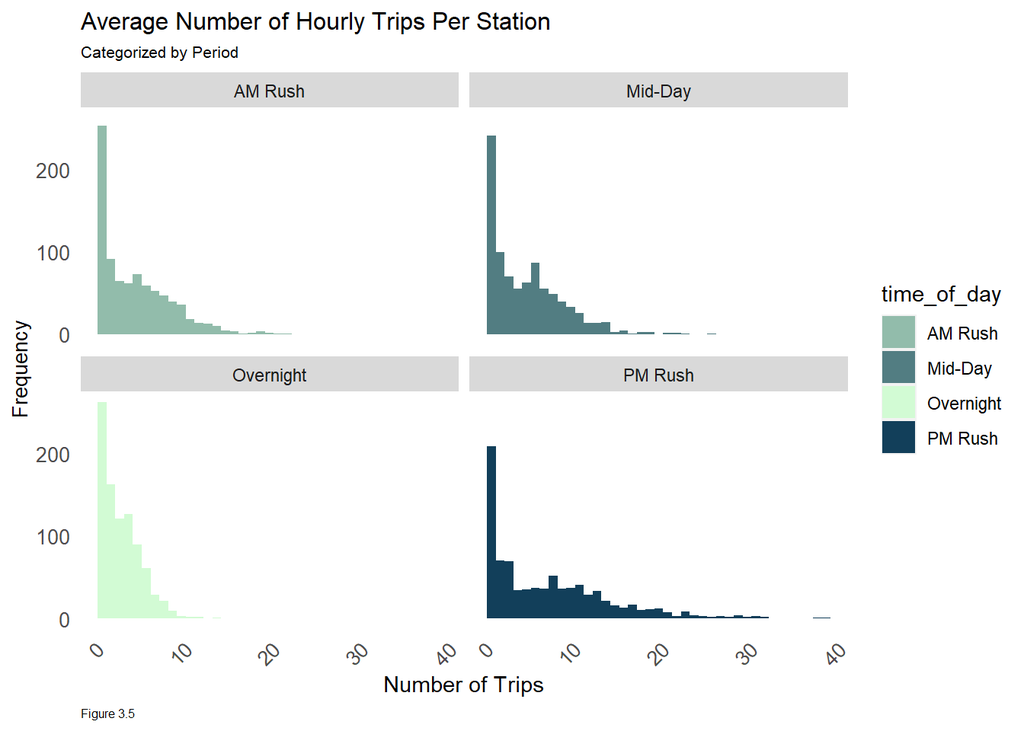

```r
dat2 %>%
  mutate(time_of_day = case_when(hour(interval60) < 7 | hour(interval60) > 18 ~ "Overnight",
                                 hour(interval60) >= 7 & hour(interval60) < 10 ~ "AM Rush",
                                 hour(interval60) >= 10 & hour(interval60) < 15 ~ "Mid-Day",
                                 TRUE ~ "PM Rush"))%>%
  group_by(interval60, start_station_name, time_of_day) %>%
  tally()%>%
  group_by(start_station_name, time_of_day)%>%
  summarize(mean_trips = mean(n))%>%
  ggplot(aes(x = mean_trips, fill = time_of_day))+
  geom_histogram(binwidth = 1)+
  labs(title="Average Number of Hourly Trips Per Station",
       subtitle = "Categorized by Period",
       caption="Figure 3.5",
       x="Number of Trips",
       y="Frequency")+
  facet_wrap(~time_of_day) +
  scale_fill_manual(values = c("Overnight" = "#D2FBD4", "AM Rush" = "#92BCAB", "Mid-Day" = "#527D82", "PM Rush" = "#123F5A")) +
  plotTheme+
        theme(plot.caption = element_text(hjust = 0)) +
        theme(panel.grid.major = element_blank())
```

```r
# palette4 <- c("#D2FBD4","#92BCAB","#527D82","#123F5A")

#  scale_fill_manual(values = c("Overnight" = "#6baed6", "AM Rush" = "#0050B5", "Mid-Day" = "#3182bd", "PM Rush" = "#0050B5"))
```

### 3.3.2: Trip by Day

Figure 3.6.1 illustrates total trip counts across all stations by hour by day of the week. This figure is another illustration of the temporal relationship between bikeshare demand and time of day. From this figure we can clearly see the peaks in ridership during the `AM Rush` and the `PM Rush`. Between the two periods, we see that there is a more prominent peak during the `PM Rush` period, suggesting that there are more Citibike riders in the evening.

Figure 3.6.2 illustrates the total trip counts observed on weekends versus weekdays. The weekday trend line shows the clear morning and evening peaks. This trend is not evident with our weekend data. We see that total trips over the weekend does not have drastic and clear peak periods, but rather there is a gradual increase in demand from morning to mid-day before the demand gradually declines. This shows that there is a difference in ridership patterns on weekdays versus weekends, and this temporal pattern should also be considered when building the predictive rideshare model.

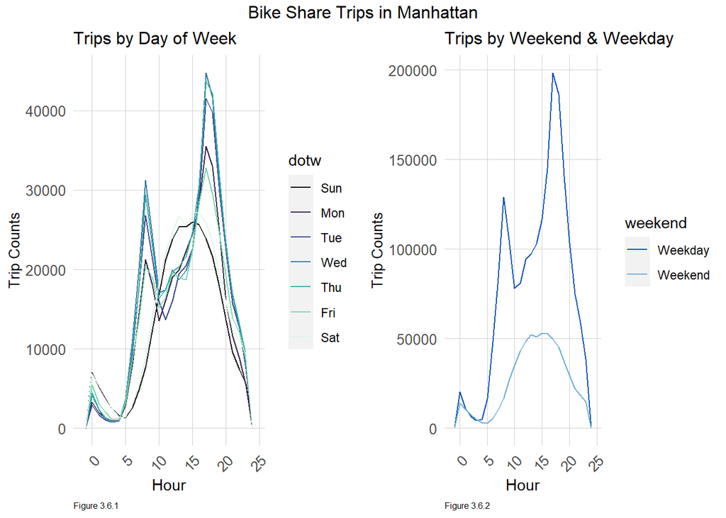

```r
grid.arrange(
  # days of week
  ggplot(dat2 %>%
    mutate(hour = hour(started_at)))+
    geom_freqpoly(aes(hour, color = dotw), binwidth = 1)+
    scale_colour_viridis(discrete = TRUE, option = "G")+
    labs(title="Trips by Day of Week",
         caption = "Figure 3.6.1",
         x="Hour",
         y="Trip Counts")+
       plotTheme+
        theme(plot.caption = element_text(hjust = 0)),

  # weekend and weekday
  ggplot(dat2 %>%
           mutate(hour = hour(started_at),
                  weekend = ifelse(dotw %in% c("Sun", "Sat"), "Weekend", "Weekday")))+
       geom_freqpoly(aes(hour, color = weekend), binwidth = 1)+
    labs(title="Trips by Weekend & Weekday",
         caption = "Figure 3.6.2",
         x="Hour",
         y="Trip Counts")+
        scale_color_manual(values = c("Weekday" = "#0050B5", "Weekend" = "#6baed6")) +
       plotTheme+
        theme(plot.caption = element_text(hjust = 0)),
  top="Bike Share Trips in Manhattan", ncol =2)
```

### 3.3.3: Temporal Travel Patterns

Figure 3.7 shows the overall time-space patterns of bike share trips across all stations in Manhattan. This highlights the fact that there the demand for bikes is driven by spatial and temporal features. The maps also show us that demand is typically concentrated within downtown Manhattan, and it seems to be the area with the highest ridership across all time periods.

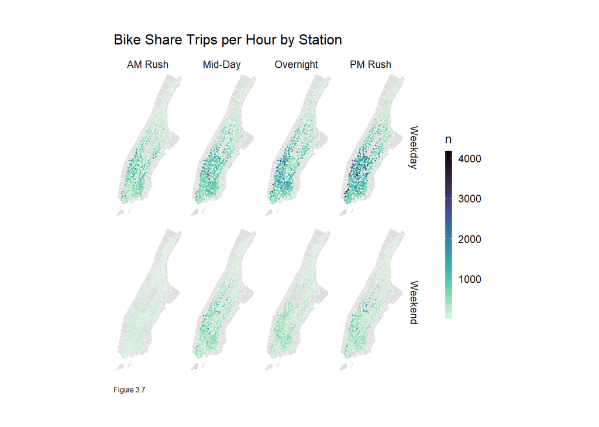

```r
ggplot()+
  geom_sf(data = nycTracts %>%
          st_transform(crs=4326), fill="#e0e0e0",color = "white")+
  geom_point(data = dat2 %>%
            mutate(hour = hour(started_at),
                weekend = ifelse(dotw %in% c("Sun", "Sat"), "Weekend", "Weekday"),
                time_of_day = case_when(hour(interval60) < 7 | hour(interval60) > 18 ~ "Overnight",
                                 hour(interval60) >= 7 & hour(interval60) < 10 ~ "AM Rush",
                                 hour(interval60) >= 10 & hour(interval60) < 15 ~ "Mid-Day",
                                 TRUE ~ "PM Rush"))%>%
              group_by(start_station_name, start_lng, start_lat, weekend, time_of_day) %>%
              tally(),
            aes(x=start_lng, y = start_lat, color = n),
            fill = "transparent", alpha = 0.8, size = 0.3)+
  scale_colour_viridis(direction = -1, discrete = FALSE, option = "G")+
  ylim(min(dat2$start_lat), max(dat2$start_lat))+
  xlim(min(dat2$start_lng), max(dat2$start_lng))+
  facet_grid(weekend ~ time_of_day)+
  labs(title="Bike Share Trips per Hour by Station",
       caption = "Figure 3.7")+
  mapTheme+
  theme(plot.caption = element_text(hjust = 0)) +
  theme(panel.grid.major = element_blank(),
        strip.background = element_blank())
```

## 3.4: Trips by Weather

In this section, I explore bike share demand in relationship to weather related features. As discussed, the features explored are temperature, wind speed, and precipitation.

### 3.4.1: Trips by Temperature

Figure 3.8 shows the average trip count by station per week, classified by temperature. As we can see from this graph, there is a very strong positive relationship between temperature and number of trips. There are typically a higher number of trips when the temperature is higher. This suggests that riders are more likely to use Citi bike when the weather is warmer, and less likely to ride when it is cold.

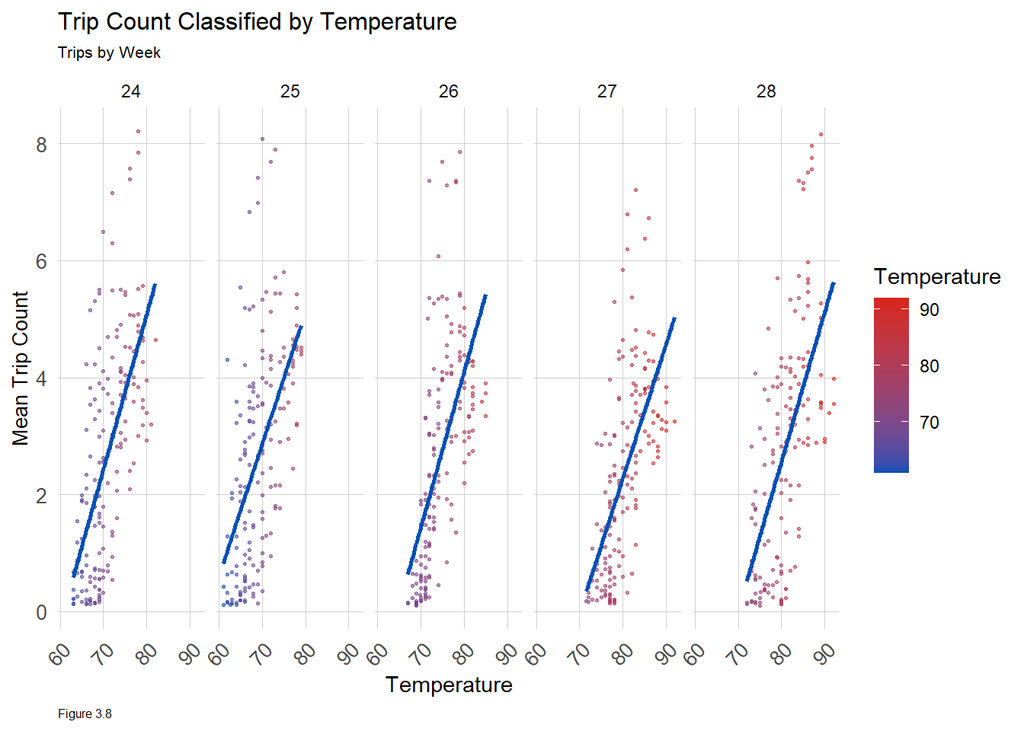

```r
# temperature with trip counts
st_drop_geometry(ride.panel) %>%
  group_by(interval60) %>%
  summarize(Trip_Count = mean(Trip_Count),
            Temperature = first(Temperature)) %>%
  mutate(week = week(interval60)) %>%
  ggplot(aes(Temperature, Trip_Count)) +
  geom_point(aes(color=Temperature), size = 0.6, alpha= 0.6) +
    scale_color_gradient(low="#0050B5", high="#D9261C") +
    geom_smooth(method = "lm", se= FALSE, color = "#0050B5") +
    facet_wrap(~week, ncol=8) +
    labs(title="Trip Count Classified by Temperature",
         subtitle = "Trips by Week",
         caption="Figure 3.8",
         x="Temperature", y="Mean Trip Count") +
    plotTheme +
    theme(strip.background = element_blank())+
    theme(plot.caption = element_text(hjust = 0))
```

### 3.4.2: Trips by Wind Speed

Figure 3.9 shows the relationship between wind speed and Citi bike ridership. From this we see that there is generally a positive relationship between wind speed and ridershp. As wind speed increases, so does ridership.

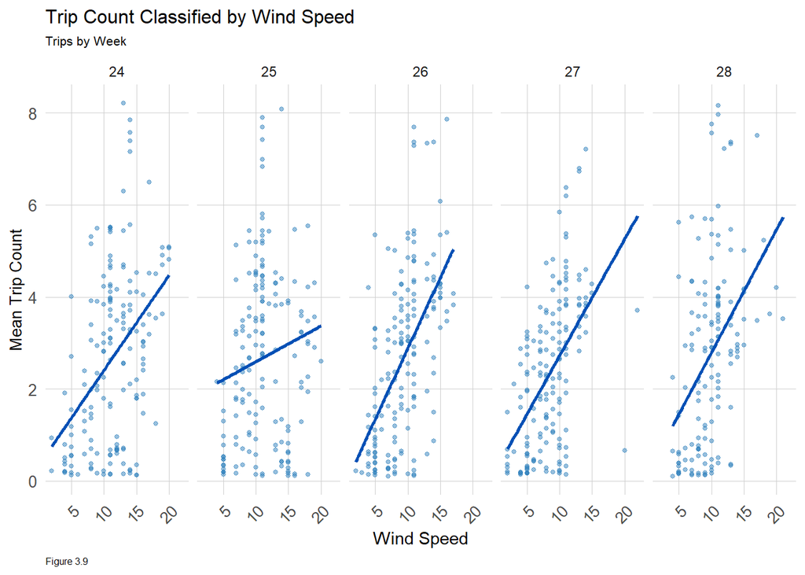

```r
st_drop_geometry(ride.panel) %>%
  group_by(interval60) %>%
  summarize(Trip_Count = mean(Trip_Count),
            Wind_Speed = first(Wind_Speed)) %>%
  mutate(week = week(interval60)) %>%
  ggplot(aes(Wind_Speed, Trip_Count)) +
    geom_point(size = 1, color ="#3182bd", alpha= 0.5) +
    geom_smooth(method = "lm", se= FALSE, color = "#0050B5") +
    facet_wrap(~week, ncol=8) +
    labs(title="Trip Count Classified by Wind Speed",
         subtitle = "Trips by Week",
         caption="Figure 3.9",
         x="Wind Speed", y="Mean Trip Count") +
    plotTheme +
    theme(strip.background = element_blank())+
    theme(plot.caption = element_text(hjust = 0))
```

### 3.4.3: Trips by Precipiration

Figure 3.10 shows the relationship between Citi bike ridership and precipitation. Overall, we see that there is some negative correlation between rainfall and ridership. However, it is difficult to make a conclusive assumption about the relationship between precipitation and ridership since the data on precipitation is so limited. If we were to make an educated assumption, we might assume that higher precipitation would result in lower ridership rates.

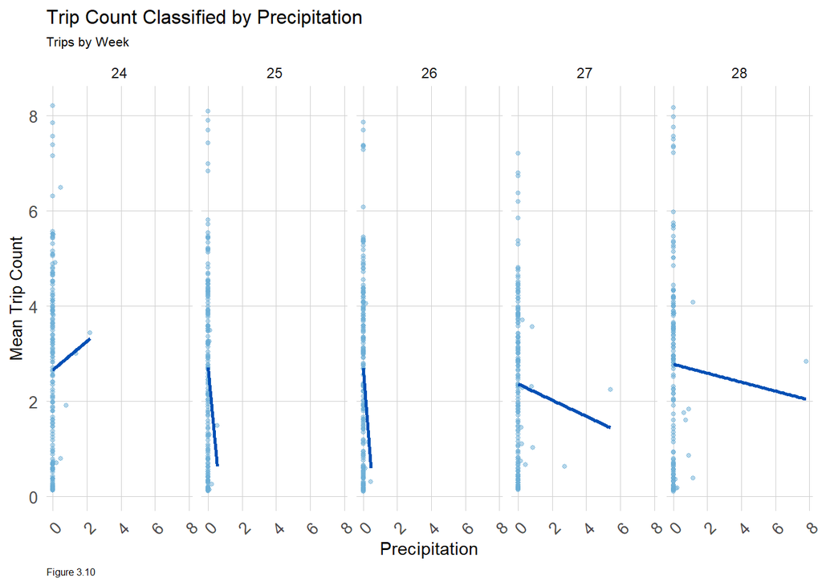

```r
# precipitation with trip counts
st_drop_geometry(ride.panel) %>%
  group_by(interval60) %>%
  summarize(Trip_Count = mean(Trip_Count),
            Precipitation = first(Precipitation)) %>%
  mutate(week = week(interval60)) %>%
  ggplot(aes(Precipitation, Trip_Count)) +
    geom_point(size = 1, color ="#6baed6", alpha= 0.5) +
    geom_smooth(method = "lm", se= FALSE, color = "#0050B5") +
    facet_wrap(~week, ncol=8) +
    labs(title="Trip Count Classified by Precipitation",
         subtitle = "Trips by Week",
         caption="Figure 3.10",
         x="Precipitation", y="Mean Trip Count") +
    plotTheme +
    theme(strip.background = element_blank())+
    theme(plot.caption = element_text(hjust = 0))
```

# 4: Ride Share Prediction

After exploring our data, we are ready to train the ride share prediction model. In this section, I will go over the models that I built and compare the performance of each model.

## 4.1: Training the Models

In this section, I have three different linear regressions, each with a different fixed effects:

- `reg1` or **A_Time_FE**: Considers only temporal and weather variables
- `reg2` or **B_TimeSpace_FE**: considers temporal, weather, and spatial variables
- `reg3` or **C_TimeSpaceLag_FE**: considers temporal, weather, spatial variables and time lag

```r
# dotw - station
reg1 <-
  lm(Trip_Count ~ hour(interval60) + dotw + Temperature + Wind_Speed,
     data=ride.Train)

reg2 <-
  lm(Trip_Count ~  start_station_name + hour(interval60) + dotw + Temperature + Wind_Speed, data=ride.Train)

reg3 <-
  lm(Trip_Count ~ start_station_name + hour(interval60) +dotw + Temperature + Wind_Speed + lagHour + lag2Hours + lag3Hours + lag12Hours +lag1day + holiday, data = ride.Train)
```

```r
ride.Test.weekNest <-
  ride.Test %>%
  nest(-week)
```

```r
model_pred <- function(dat, fit){
   pred <- predict(fit, newdata = dat)}
```

## 4.2: Comparing Model Performance

After running each regression by using the test set, I compared the performance of each model. To do this, I looked at the Mean Absolute Error (MAE) and predicted versus observed outcomes.

```r
week_predictions <-
  ride.Test.weekNest %>%
    mutate(A_Time_FE = map(.x = data, fit = reg1, .f = model_pred),
           B_SpaceTime_FE = map(.x = data, fit = reg2, .f = model_pred),
           C_SpaceTimeLag_FE = map(.x = data, fit = reg3, .f = model_pred)) %>%
    gather(Regression, Prediction, -data, -week) %>%
    mutate(Observed = map(data, pull, Trip_Count),
           Absolute_Error = map2(Observed, Prediction,  ~ abs(.x - .y)),
           MAE = map_dbl(Absolute_Error, mean, na.rm = TRUE),
           sd_AE = map_dbl(Absolute_Error, sd, na.rm = TRUE))
```

### 4.2.1: Mean Absolute Error

Figure 4.1 shows the Mean Absolute Error of each of the three models. Our of the three models, the third, `C_SpaceTimeLag_FE` model had the lowest MAE values. The difference was also significant, with the third model producing MAEs twice as low as the first model, `A_Time_FE`. This shows that incorporating the temporal, spatial, weather, anf time lag variable contributed significantly to the performance of the model.

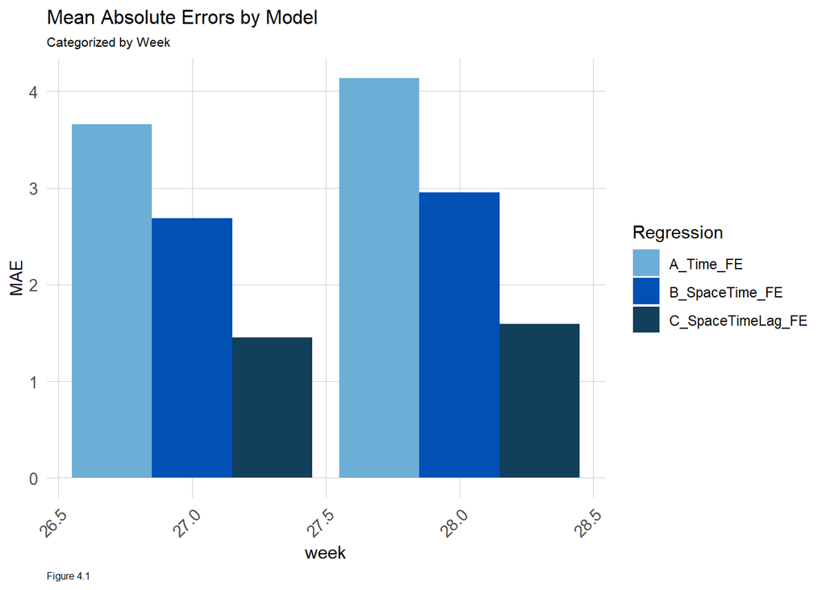

```r
week_predictions %>%
  dplyr::select(week, Regression, MAE) %>%
  gather(Variable, MAE, -Regression, -week) %>%
  ggplot(aes(week, MAE)) +
    geom_bar(aes(fill = Regression), position = "dodge", stat="identity") +
    scale_fill_manual(values = palette2) +
    labs(title = "Mean Absolute Errors by Model",
         subtitle = "Categorized by Week",
         caption = "Figure 4.1") +
  plotTheme +
  theme(strip.background = element_blank()) +
  theme(plot.caption = element_text(hjust = 0))
```

### 4.2.2: Predicted Versus Obeserved Values

Figure 4.2 shows the performance of all three models, comparing the predicted station trips to the actual observed trips. Out of the three models, the `C_TimeSpaceLag_FE` model performed the best. Like the results observed in the previous section, the overall error captured between predicted and observed values was the lowest for the third model. While the third model performed the best, the predictions were not perfect. Here, we see that the models still struggled to predict extreme values, at times under-predicting and over-predicting.

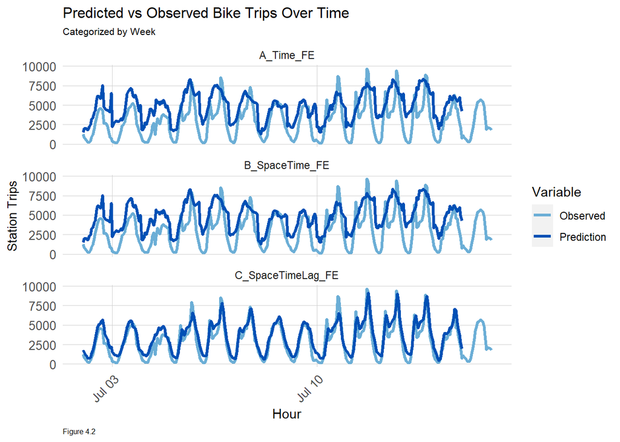

```r
week_predictions %>%
    mutate(interval60 = map(data, pull, interval60),
           start_station_name = map(data, pull, start_station_name)) %>%
    dplyr::select(interval60, start_station_name, Observed, Prediction, Regression) %>%
    unnest() %>%
    gather(Variable, Value, -Regression, -interval60, -start_station_name) %>%
    group_by(Regression, Variable, interval60) %>%
    summarize(Value = sum(Value)) %>%
    ggplot(aes(interval60, Value, colour=Variable)) +
      geom_line(size = 1.1) +
      facet_wrap(~Regression, ncol=1) +
      scale_color_manual(values = palette2) +
      labs(title = "Predicted vs Observed Bike Trips Over Time",
           subtitle = "Categorized by Week",
           caption = "Figure 4.2",
           x = "Hour", y= "Station Trips") +
      plotTheme +
  theme(strip.background = element_blank()) +
  theme(plot.caption = element_text(hjust = 0))
```

## 4.3: Time-Space Evaluation

Based on the previous analysis, I concluded that the third model, `C_SpaceTimelag_FE` model performed the best overall. Using this model moving forward, I will examine the goodness of fit of the model and its predictive abilities. Figure 4.3 shows the MAE performance of model C. The figure shows that the highest MAE is observed around lower Manhattan to midtown area. This suggests that the model is either under-predicting or over-predicting for areas with higher ridership demands.

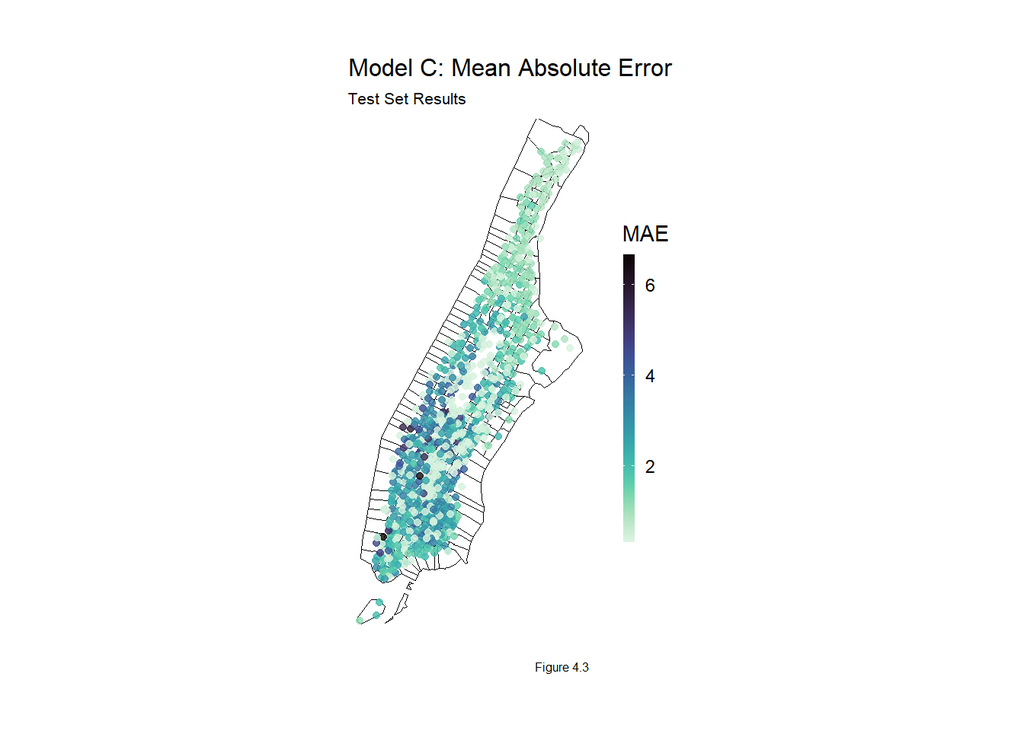

```r
week_predictions %>%
    mutate(interval60 = map(data, pull, interval60),
           start_station_name = map(data, pull, start_station_name),
           start_lat = map(data, pull, start_lat),
           start_lng = map(data, pull, start_lng)) %>%
    select(interval60, start_station_name, start_lat, start_lng, Observed, Prediction, Regression) %>%
    unnest() %>%
  filter(Regression == "C_SpaceTimeLag_FE") %>%
  group_by(start_station_name, start_lat, start_lng) %>%
  summarize(MAE = mean(abs(Observed-Prediction), na.rm = TRUE))%>%
ggplot(.)+
  geom_sf(data = nycTracts, color = "black", fill = "transparent")+
  geom_point(aes(x = start_lng, y = start_lat, color = MAE),
             fill = "transparent", alpha = 0.8)+
  scale_colour_viridis(direction = -1,
  discrete = FALSE, option = "G")+
  ylim(min(dat2$start_lat), max(dat2$start_lat))+
  xlim(min(dat2$start_lng), max(dat2$start_lng))+
  labs(title="Model C: Mean Absolute Error",
       subtitle = "Test Set Results",
       caption = "Figure 4.3") +
  mapTheme +
  theme(panel.grid.major = element_blank(),
        strip.background = element_blank())
```

[figure not shown]

```r
week_predictions %>%
    mutate(interval60 = map(data, pull, interval60),
           start_station_name = map(data, pull, start_station_name),
           start_lat = map(data, pull, start_lat),
           start_lng = map(data, pull, start_lng),
           dotw = map(data, pull, dotw)) %>%
    select(interval60, start_station_name, start_lng,
           start_lat, Observed, Prediction, Regression,
           dotw) %>%
    unnest() %>%
  filter(Regression == "C_SpaceTimeLag_FE")%>%
  mutate(weekend = ifelse(dotw %in% c("Sun", "Sat"), "Weekend", "Weekday"),
         time_of_day = case_when(hour(interval60) < 7 | hour(interval60) > 18 ~ "Overnight",
                                 hour(interval60) >= 7 & hour(interval60) < 10 ~ "AM Rush",
                                 hour(interval60) >= 10 & hour(interval60) < 15 ~ "Mid-Day",
                                 hour(interval60) >= 15 & hour(interval60) <= 18 ~ "PM Rush"))%>%
  group_by(start_station_name, weekend, time_of_day, start_lng, start_lat) %>%
  summarize(MAE= mean(Observed-Prediction), na.rm = TRUE) %>%
  ggplot(.)+
  geom_sf(data=nycTracts, color = "black", fill = "transparent") +
  geom_point(aes(x = start_lng, y = start_lat, color = MAE),
               fill = "transparent", size = 0.5, alpha = 0.6)+
    scale_color_viridis(direction = -1, discrete = FALSE, option = "G")+
    ylim(min(dat2$start_lat), max(dat2$start_lat))+
    xlim(min(dat2$start_lng), max(dat2$start_lng))+
    facet_grid(weekend~time_of_day)+
    labs(title="Mean Absolute Errors by Time Period",
         subtitle = "Weekday vs Weekend",
         caption = "Figure 4.4")+
    mapTheme+
    theme(plot.caption = element_text(hjust = 0))
```

## 4.4: Temporal Feature Evaluation

In this section, I looked at the performance of model C over different periods of time. Figure 4.5 shows the differences between observed and predicted outcomes in the number of trips. The outcomes are tested against time period and if the trip occurred on a weekday or weekend. Based on the plot, we see that the model predicted slightly better for weekend values over weekday values. For weekday trips, the model performed better when predicting for mid-day and overnight demand over AM and PM rush. This test shows that the model under-predicts for periods with higher demand. This finding is in line with patterns identified in earlier sections.

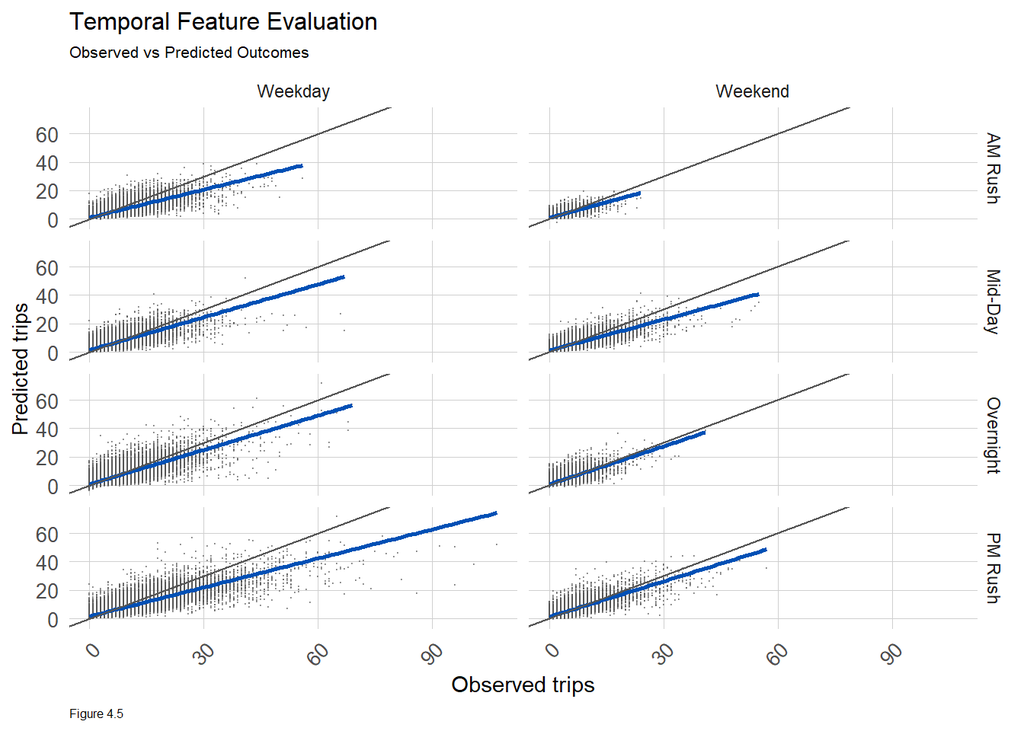

```r
# comparing predicting accuracy by different time in a day and weekend/weekdays
week_predictions %>%
    mutate(interval60 = map(data, pull, interval60),
           start_station_name = map(data, pull, start_station_name),
           start_lat = map(data, pull, start_lat),
           start_lng = map(data, pull, start_lng),
           dotw = map(data, pull, dotw)) %>%
    select(interval60, start_station_name, start_lng,
           start_lat, Observed, Prediction, Regression,
           dotw) %>%
    unnest() %>%
  filter(Regression == "C_SpaceTimeLag_FE") %>%
  mutate(weekend = ifelse(dotw %in% c("Sun", "Sat"), "Weekend", "Weekday"),
         time_of_day = case_when(hour(interval60) < 7 | hour(interval60) > 18 ~ "Overnight",
                                 hour(interval60) >= 7 & hour(interval60) < 10 ~ "AM Rush",
                                 hour(interval60) >= 10 & hour(interval60) < 15 ~ "Mid-Day",
                                 hour(interval60) >= 15 & hour(interval60) <= 18 ~ "PM Rush"))%>%
  ggplot()+
  geom_point(aes(x= Observed, y = Prediction), color="#555555", alpha = 0.5, size = 0.1)+
    geom_smooth(aes(x= Observed, y= Prediction), method = "lm", se = FALSE, color = "#0050B5")+
    geom_abline(slope = 1, intercept = 0, color="#555555")+
  facet_grid(time_of_day~weekend)+
  labs(title="Temporal Feature Evaluation",
       subtitle = "Observed vs Predicted Outcomes",
       caption = "Figure 4.5",
       x="Observed trips",
       y="Predicted trips")+
   plotTheme +
    theme(strip.background = element_blank())+
    theme(plot.caption = element_text(hjust = 0))
```

## 4.5: Accounting for Socio-Economic Features

While socio-economic features were not heavily emphasized in this study, it is a factor that should be considered when building a more comprehensive model. Greater investigation into the relationship between socio-economic features might help improve the predictive power of this model. In Figure 4.6, I plot the errors associated with median income, percentage of commuters taking public transit, and percentage of white population. Based on the graph, we may assume that the model is less accurate at predicting Citi bike ridership demand if an area has higher median income, a lower percentage of commuters who take public transit, and if the population is more white. If an area has a higher proportion of people who commute by public transit, the model is better at predicting bike share demand in the area. The investigation on socio-economic features are very basic and may not be very helpful for the model at this stage. However, moving forward, fine tuning this feature may serve the more helpful in creating a more predictive model.

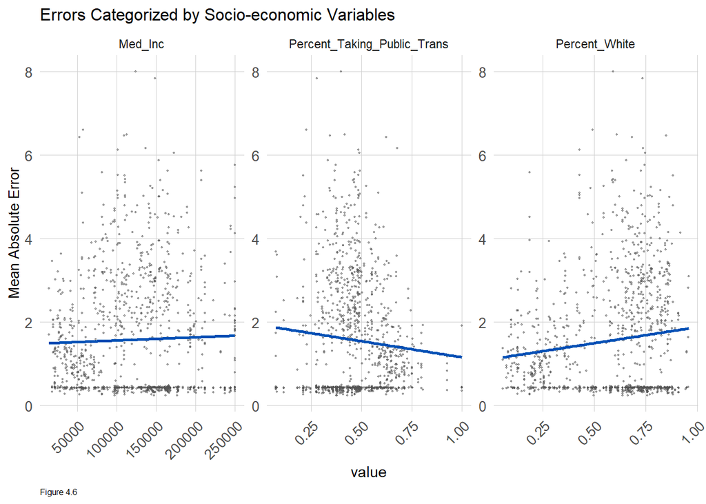

```r
week_predictions %>%
    mutate(interval60 = map(data, pull, interval60),
           start_station_name = map(data, pull, start_station_name),
           start_lat = map(data, pull, start_lat),
           start_lng = map(data, pull, start_lng),
           dotw = map(data, pull, dotw),
           Percent_Taking_Public_Trans = map(data, pull, Percent_Taking_Public_Trans),
           Med_Inc = map(data, pull, Med_Inc),
           Percent_White = map(data, pull, Percent_White)) %>%
    select(interval60, start_station_name, start_lng,
           start_lat, Observed, Prediction, Regression,
           dotw, Percent_Taking_Public_Trans, Med_Inc, Percent_White) %>%
    unnest() %>%
  filter(Regression == "C_SpaceTimeLag_FE")%>%
  mutate(weekend = ifelse(dotw %in% c("Sun", "Sat"), "Weekend", "Weekday"),
         time_of_day = case_when(hour(interval60) < 7 | hour(interval60) > 18 ~ "Overnight",
                                 hour(interval60) >= 7 & hour(interval60) < 10 ~ "AM Rush",
                                 hour(interval60) >= 10 & hour(interval60) < 15 ~ "Mid-Day",
                                 hour(interval60) >= 15 & hour(interval60) <= 18 ~ "PM Rush")) %>%
  filter(time_of_day == "AM Rush") %>%
  group_by(start_station_name, Percent_Taking_Public_Trans, Med_Inc, Percent_White) %>%
  summarize(MAE = mean(abs(Observed-Prediction), na.rm = TRUE))%>%
  gather(-start_station_name, -MAE, key = "variable", value = "value")%>%
  ggplot(.)+
  #geom_sf(data = chicagoCensus, color = "grey", fill = "transparent")+
  geom_point(aes(x = value, y = MAE), color="#555555", alpha = 0.5, size = 0.4)+
  geom_smooth(aes(x = value, y = MAE), method = "lm", se= FALSE, color = "#0050B5")+
  facet_wrap(~variable, scales = "free")+
  labs(title="Errors Categorized by Socio-economic Variables",
       y="Mean Absolute Error",
       caption = "Figure 4.6",)+
  plotTheme+
    theme(strip.background = element_blank())+
    theme(plot.caption = element_text(hjust = 0))
```

# 5: Interpreting the Predictions

Based on the exploration into the Citi bike rideshare data, I can conclude that to successfully predict rideshare demand, the model should account for temporal, spatial, and lag variables. After testing multiple models, the most accurate model included all three variables. However, with the current model, there are still systemic errors in the predictions. As seen in the investigation, the current model still under-predicts for high ride share demand areas. Although the current model is lacking, it gives us important insights into the use of Citibike Bikes through Manhattan across time and space.

Moving forward, I have a few pointers for improvement of the existing model. For this exercise, I only used data for Manhattan across a short period of time. To improve the overall performance, it would be helpful to increase the scope of the study. This can be done by looking at ridership patterns across all boroughs of New York City, Jersey City, and Hoboken. Moreover, I only focused the study on the months of June to July. It might be helpful to get an understanding of ridership patterns throughout various seasons, and not just across the summer months.

Lastly, to improve the existing model, with limited data, it might be worth spending more time to have more sophisticated feature engineering that will capture more nuanced circumstances such as holidays and weather-related behaviors. Overall, this investigation is a good start, but there are many areas which the work can be improved upon.

# 6: Acknowledgement

This code was worked on in collaboration with my partner, Xiaofan Liu.